# Reproducible Research: Peer Assessment 1

## Loading and preprocessing the data

The goal of this project is to present some basic info and investigations into a sample of data concerning the walking habits of single person at all times throughout the day for a few months.

## What is mean total number of steps taken per day?

In this project we take a look at the subjects walking habits. The first step in this process is loading the data and building a data frame.

```r
df <- read.csv(unz("activity.zip",
                   "activity.csv"),
               stringsAsFactors = FALSE)
head(df)
```

```
##   steps       date interval
## 1    NA 2012-10-01        0
## 2    NA 2012-10-01        5
## 3    NA 2012-10-01       10
## 4    NA 2012-10-01       15
## 5    NA 2012-10-01       20
## 6    NA 2012-10-01       25
```

We can see the data has plenty of missing values in the steps variable just at the top. For now, we will omit them from our data. We load the dplyr package to create a histogram of the number of total number of steps taken by the participant during each day.

```r
library(dplyr)
```

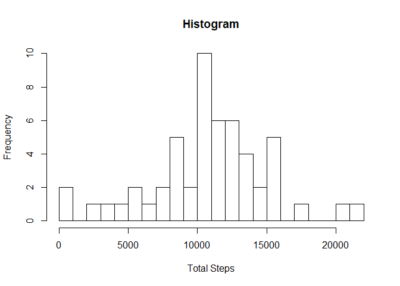

```r
dframe1 <- df %>%
  filter(!is.na(steps)) %>%
  group_by(date) %>%
  summarize(totalSteps = sum(steps))

dframe1 <- data.frame(dframe1)

hist(dframe1$totalSteps,breaks = 30,
     main = "Histogram",
     xlab = "Total Steps")
```

```r
mean(dframe1$totalSteps)
```

```
## [1] 10766.19
```

## What is the average daily activity pattern?

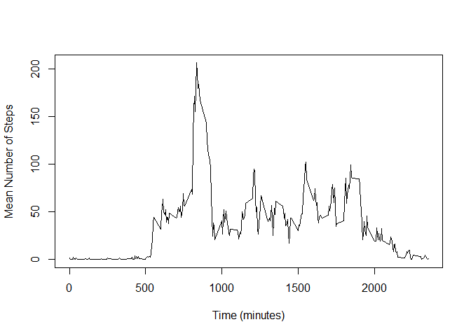

```r
dframe2 <- df %>%
  filter(!is.na(steps)) %>%
  group_by(interval) %>%
  summarize(meanSteps = mean(steps))

dframe2 <- data.frame(dframe2)

plot(dframe2$interval,
     dframe2$meanSteps,
     xlab = "Time (minutes)",
     ylab = "Mean Number of Steps",
     type = "l")
```

From this we see several spikes in the subjects walking habits. The maximum mean number of steps at any time is

```r
max(dframe2$meanSteps)
```

```
## [1] 206.1698
```

## Imputing missing values

```r
  length(which(is.na(df$steps)))
```

```
## [1] 2304
```

This may not be the optimal method, but our approach is to merge two data frames (the original df and the most recent) to create a copy of the original file with missing values filled in, as seen below.

```r
dframe <- merge(df,dframe2, by = "interval")
x <- which(is.na(dframe$steps))
dframe$steps[x] <- dframe$meanSteps[x]

dframe <- dframe %>% select(steps,date,interval)

dframe <- data.frame(dframe)

dframe <- arrange(dframe,date,interval)
head(dframe)
```

```
##       steps       date interval
## 1 1.7169811 2012-10-01        0
## 2 0.3396226 2012-10-01        5
## 3 0.1320755 2012-10-01       10
## 4 0.1509434 2012-10-01       15
## 5 0.0754717 2012-10-01       20
## 6 2.0943396 2012-10-01       25
```

Next we create a new histogram from this data and compare it to the original, which excluded missing values.

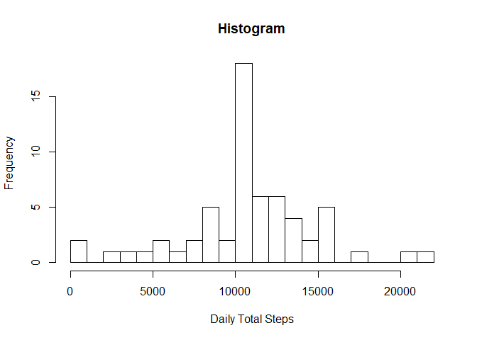

```r
dframe4 <- dframe %>% group_by(date) %>%
  summarize(totalSteps = sum(steps))

dframe4 <- data.frame(dframe4)
hist(dframe4$totalSteps,breaks=30,main = "Histogram",xlab = "Daily Total Steps")
```

Here, we see that the result is more concentrated around 10000, with narrower tails. We also compare the means to those earlier:

```r
  mean(dframe4$totalSteps)
```

```
## [1] 10766.19
```

```r
  median(dframe4$totalSteps)
```

```
## [1] 10766.19
```

The equality here seems suspicious but I can’t find my mistake. However, by “averaging out” the data set, we should expect the mean to be unaffected and the median to approach it.

## Are there differences in activity patterns between weekdays and weekends?

Below we use the orginal data frame created with missing values filled in to create a data frame with a factor variable for weekends and weekdays. We use the “weekdays()” function and merge the new data frame with a easily constructed one matching days of the week to their categories (“Weekday” or “Weekend”)

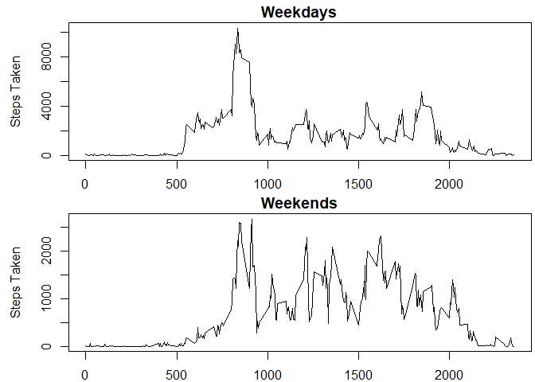

```r
dframe5 <- dframe

dframe5$date <- weekdays(as.Date(dframe5$date))

week <- as.character(c("Monday",
                  "Tuesday","Wednesday",
                  "Thursday","Friday",
                  "Saturday","Sunday"))

cat <- as.character(c(rep("Weekday",5),
                      rep("Weekend",2)))

vf <- cbind(week,cat)
vf <- data.frame(vf)

names(vf) <- c("date","cat")

mergeTable <- merge(dframe5,vf,by = "date")

mergeTable <- data.frame(mergeTable)

mergeTable$cat <- factor(mergeTable$cat)

mergeTable2 <- mergeTable %>%
  filter(cat == "Weekday") %>%
    group_by(interval) %>%
    summarize(totalSteps = sum(steps))

mergeTable3 <- mergeTable %>%
  filter(cat == "Weekend") %>%
  group_by(interval) %>%
  summarize(totalSteps = sum(steps))

par(mfrow = c(2,1),mai = c(.4,.9,.3,.05))

plot(mergeTable2$interval,
     mergeTable2$totalSteps,
     type = "l",
     main = "Weekdays",
     xlab = "Time (minutes)",
     ylab = "Steps Taken")
plot(mergeTable3$interval,
     mergeTable3$totalSteps,
     type = "l", main = "Weekends",
     xlab = "Time (minutes)",
     ylab = "Steps Taken")
```

Here we have plotted the line graphs of the subject on weekdays and weekends. At first glance, from this we can that the habits are to walk less early in the day and more in the afternoon and evening. However, the raw numbers are smaller, with less substantial peaks, and a more even spread throughout the later day.